# I want to work at Mathematica.

Celeste Coughlin

2023-02-18

## R Markdown Code Sample

This is an example of Celeste Coughlin’s approach to R.

```r
library(r4np)
library(tidyverse)
library(countrycode)
head(wvs)
```

```
## # A tibble: 6 × 7
##   `Participant ID` `Country name` Gender   Age relationship_st…¹ Freed…² Satis…³
##              <dbl> <chr>           <dbl> <dbl> <chr>               <dbl>   <dbl>
## 1         20070001 Andorra             1    60 married                10      10
## 2         20070002 Andorra             0    47 living together …       9       9
## 3         20070003 Andorra             0    48 separated               9       9
## 4         20070004 Andorra             1    62 living together …       9       8
## 5         20070005 Andorra             0    49 living together …       8       7
## 6         20070006 Andorra             1    51 married                10      10
## # … with abbreviated variable names ¹relationship_status, ²Freedom.of.Choice,
## #   ³`Satisfaction-with-life`
```

```r
tail(wvs)
```

```
## # A tibble: 6 × 7
##   `Participant ID` `Country name` Gender   Age relationship_st…¹ Freed…² Satis…³
##              <dbl> <chr>           <dbl> <dbl> <chr>               <dbl>   <dbl>
## 1        840073591 United States       1    25 single                 10      10
## 2        840073592 United States       1    42 single                  3       5
## 3        840073593 United States       0    42 divorced                7       7
## 4        840073594 United States       1    27 single                  9       8
## 5        840073595 United States       0    22 living together …       8       9
## 6        840073596 United States       1    38 separated              10      10
## # … with abbreviated variable names ¹relationship_status, ²Freedom.of.Choice,
## #   ³`Satisfaction-with-life`
```

```r
skimr::skim(wvs)
```

Data summary

| Name | wvs |
| --- | --- |
| Number of rows | 69578 |
| Number of columns | 7 |
| _______________________ |  |
| Column type frequency: |  |
| character | 2 |
| numeric | 5 |
| ________________________ |  |
| Group variables | None |

**Variable type: character**

| skim_variable | n_missing | complete_rate | min | max | empty | n_unique | whitespace |
| --- | --- | --- | --- | --- | --- | --- | --- |
| Country name | 0 | 1 | 4 | 31 | 0 | 48 | 0 |
| relationship_status | 335 | 1 | 6 | 26 | 0 | 6 | 0 |

**Variable type: numeric**

| skim_variable | n_missing | complete_rate | mean | sd | p0 | p25 | p50 | p75 | p100 | hist |
| --- | --- | --- | --- | --- | --- | --- | --- | --- | --- | --- |
| Participant ID | 0 | 1.00 | 420717935.73 | 245523343.28 | 20070001 | 196700567 | 398071274 | 630700386 | 840073596 | ▇▅▇▆▆ |
| Gender | 51 | 1.00 | 0.52 | 0.50 | 0 | 0 | 1 | 1 | 1 | ▇▁▁▁▇ |
| Age | 318 | 1.00 | 42.59 | 16.28 | 16 | 29 | 40 | 55 | 103 | ▇▇▆▂▁ |
| Freedom.of.Choice | 547 | 0.99 | 7.21 | 2.30 | 1 | 6 | 8 | 9 | 10 | ▁▂▆▇▇ |
| Satisfaction-with-life | 239 | 1.00 | 7.08 | 2.28 | 1 | 6 | 7 | 9 | 10 | ▁▂▅▇▆ |

## Cleaning Data

Clean data is easy to use. The countrycode and janitor packages help.

```r
data(wvs)
```

I must make the data have simple and easy to understand names, to ensure a smoother process.

```r
wvs_clean <- janitor::clean_names(wvs)
  wvs_clean %>%
  rename(satisfaction = satisfaction_with_life,
         country = country_name)
```

```
## # A tibble: 69,578 × 7
##    participant_id country gender   age relationship_status       freed…¹ satis…²
##             <dbl> <chr>    <dbl> <dbl> <chr>                       <dbl>   <dbl>
##  1       20070001 Andorra      1    60 married                        10      10
##  2       20070002 Andorra      0    47 living together as marri…       9       9
##  3       20070003 Andorra      0    48 separated                       9       9
##  4       20070004 Andorra      1    62 living together as marri…       9       8
##  5       20070005 Andorra      0    49 living together as marri…       8       7
##  6       20070006 Andorra      1    51 married                        10      10
##  7       20070007 Andorra      1    33 married                        10       5
##  8       20070008 Andorra      0    55 widowed                         8       8
##  9       20070009 Andorra      1    40 single                          8       8
## 10       20070010 Andorra      1    38 living together as marri…      10      10
## # … with 69,568 more rows, and abbreviated variable names ¹freedom_of_choice,
## #   ²satisfaction
```

```r
wvs_clean <- #making names of long countries shorter
  wvs_clean %>%
  mutate(country = fct_recode(country_name,
                              "Bolivia" = "Bolivia, Plurinational State of",
                              "Iran" = "Iran, Islamic Republic of",
                              "Korea" = "Korea, Republic of"))
 wvs_clean %>% mutate(countrycode (wvs_clean$country_name, origin="country.name", destination="continent"))
```

```
## # A tibble: 69,578 × 9
##    participant_id country…¹ gender   age relat…² freed…³ satis…⁴ country count…⁵
##             <dbl> <chr>      <dbl> <dbl> <chr>     <dbl>   <dbl> <fct>   <chr>
##  1       20070001 Andorra        1    60 married      10      10 Andorra Europe
##  2       20070002 Andorra        0    47 living…       9       9 Andorra Europe
##  3       20070003 Andorra        0    48 separa…       9       9 Andorra Europe
##  4       20070004 Andorra        1    62 living…       9       8 Andorra Europe
##  5       20070005 Andorra        0    49 living…       8       7 Andorra Europe
##  6       20070006 Andorra        1    51 married      10      10 Andorra Europe
##  7       20070007 Andorra        1    33 married      10       5 Andorra Europe
##  8       20070008 Andorra        0    55 widowed       8       8 Andorra Europe
##  9       20070009 Andorra        1    40 single        8       8 Andorra Europe
## 10       20070010 Andorra        1    38 living…      10      10 Andorra Europe
## # … with 69,568 more rows, and abbreviated variable names ¹country_name,
## #   ²relationship_status, ³freedom_of_choice, ⁴satisfaction_with_life,
## #   ⁵`countrycode(...)`
```

I converted some of the data types into factors for better analysis.

```r
wvs_clean <-
  wvs_clean %>%
  mutate(country = as_factor(country),
         gender = as_factor(gender),
         relationship_status = as_factor(relationship_status),
         participant_id = as_factor(participant_id))
```

## Descriptive Statistics

```r
wvs_clean <-
  wvs_clean %>%
  mutate(gender = fct_recode(gender,
                             "male" = "0",
                             "female" = "1"))
#useful renaming
wvs_clean %>% count(gender, sort = TRUE)
```

```
## # A tibble: 3 × 2
##   gender     n
##   <fct>  <int>
## 1 female 36478
## 2 male   33049
## 3 <NA>      51
```

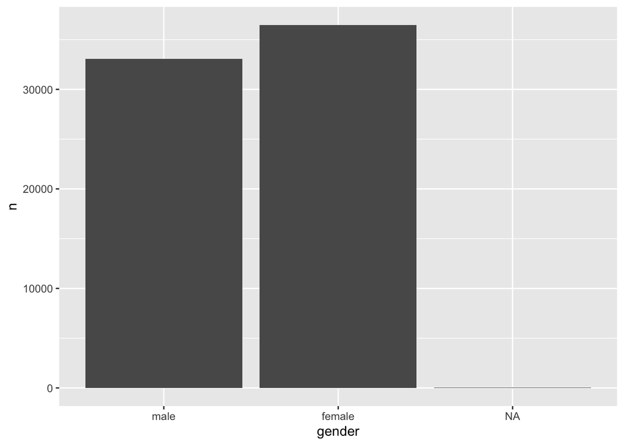

```r
wvs_clean %>%
  count(gender) %>%
  ggplot(aes(gender, n)) +
  geom_col()
```

## Charting Responses by Continent

```r
table(wvs_clean$continent)
```

```
## < table of extent 0 >
```

Next, I will generate data frames and make a simple chart.

[figure not shown]

```r
x <- c(6090,17817,43956,7845,2870)
labels <- c("Africa", "Americas", "Asia", "Europe", "Oceania")
pie(x, labels, main = "WVS Survey Responses by Continent")
```

## Conclusions

I made two simple charts to help highlight possibly biased characteristics of the data collected. One could endlessly analyze the WVS data set, but the two characteristics of gender and continent of origin of respondents start to tell a story about who generated the data present and should influence subsequent analysis as such.

Further steps to analyze this data would include comparison of responses from different continents, age ranges, and relationship status.

This is a cursory demonstration of my skills in RStudio. I am highly adaptable and eager to learn more about R, and look forward to doing so in my career as an analyst.